```python
import pandas as pd
import numpy as np
import matplotlib.pyplot as plt
import statsmodels.tsa.api as smt
from arch import arch_model
```

# Mean and Volatility Model Work Flow

## ACF and PACF Plots

```python
train = pd.read_csv('train.csv', index_col= 0, parse_dates=[0], squeeze=True)
test = pd.read_csv('test.csv', index_col= 0,parse_dates=[0], squeeze=True)
```

```python
def tsplot(y, title, lags=None, figsize=(15,10), style='bmh'):
    if not isinstance(y, pd.Series):
        y = pd.Series(y)
    with plt.style.context(style):
        fig = plt.figure(figsize=figsize)
        layout = (2, 2)
        ts_ax = plt.subplot2grid(layout, (0,0), colspan = 2)
        acf_ax = plt.subplot2grid(layout, (1,0))
        pacf_ax = plt.subplot2grid(layout, (1,1))
        y.plot(ax = ts_ax)
        ts_ax.set_title(title)
        smt.graphics.plot_acf(y, lags=lags, ax=acf_ax, alpha=0.05)
        smt.graphics.plot_pacf(y, lags = lags, ax=pacf_ax, alpha=0.05, method = "yw")
        acf_ax.set_title('Autocorrelation')
        pacf_ax.set_title('Partial Autocorrelation')
        plt.tight_layout()
    return
```

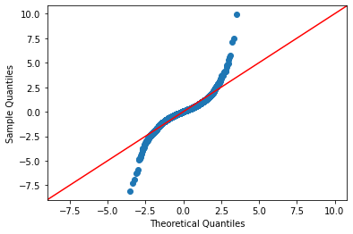

```python
import statsmodels.api as sm
std = np.std(train)
sm.qqplot(train / std, line ='45');
```

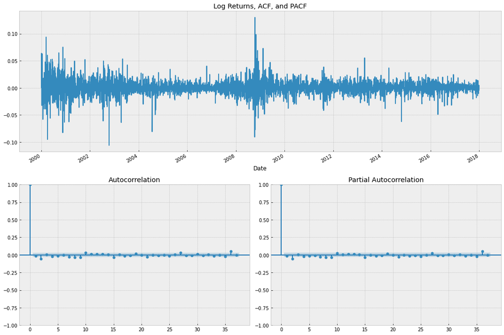

```python
tsplot(train, "Log Returns, ACF, and PACF")
```

1. The data does not look like normal from the qq plot, and it has heavier tails.
2. Both ACF and PACF have several lags that are slightly significant different from 0. To maintain a balance between interpretability and complexity. I prefer that, PACF indicates an AR(2), and ACF indicates an MA(2).

## Stationary

```python
smt.adfuller(train)
```

```
(-23.36845488643965,
 0.0,
 9,
 4517,
 {'1%': -3.4317985322285707,
  '5%': -2.862180079546209,
  '10%': -2.567110717704876},
 -26345.66930578957)
```

The ADF test shows the null can be rejected without differencing the sequence.

## ARIMA

```python
import warnings
warnings.filterwarnings('ignore')
order_sel = sm.tsa.arma_order_select_ic(train, ic=["aic", "bic"], max_ar=2, max_ma=2)

p_bic = order_sel.bic_min_order[0]
q_bic = order_sel.bic_min_order[1]
d = 0
p_aic = order_sel.aic_min_order[0]
q_aic = order_sel.aic_min_order[1]
print('BIC Order', (p_bic,d,q_bic))
print('AIC Order', (p_aic,d,q_aic))
```

```
BIC Order (0, 0, 0)
AIC Order (0, 0, 2)
```

```python
print('AIC Model')
model_aic = smt.ARIMA(train, order=(p_aic, d, q_aic))
results_aic = model_aic.fit()
print(results_aic.summary())
```

```
AIC Model
                               SARIMAX Results
==============================================================================
Dep. Variable:             LogReturns   No. Observations:                 4527
Model:                 ARIMA(0, 0, 2)   Log Likelihood               13208.475
Date:                Thu, 28 Apr 2022   AIC                         -26408.950
Time:                        17:58:55   BIC                         -26383.279
Sample:                             0   HQIC                        -26399.907
                               - 4527
Covariance Type:                  opg
==============================================================================
                 coef    std err          z      P>|z|      [0.025      0.975]
------------------------------------------------------------------------------
const          0.0002      0.000      1.129      0.259      -0.000       0.001
ma.L1         -0.0116      0.008     -1.450      0.147      -0.027       0.004
ma.L2         -0.0616      0.008     -7.526      0.000      -0.078      -0.046
sigma2         0.0002   1.69e-06    101.494      0.000       0.000       0.000
===================================================================================
Ljung-Box (L1) (Q):                   0.07   Jarque-Bera (JB):             13723.11
Prob(Q):                              0.79   Prob(JB):                         0.00
Heteroskedasticity (H):               0.28   Skew:                            -0.03
Prob(H) (two-sided):                  0.00   Kurtosis:                        11.53
===================================================================================

Warnings:
[1] Covariance matrix calculated using the outer product of gradients (complex-step).
```

## Diagonostics on ARIMA fit

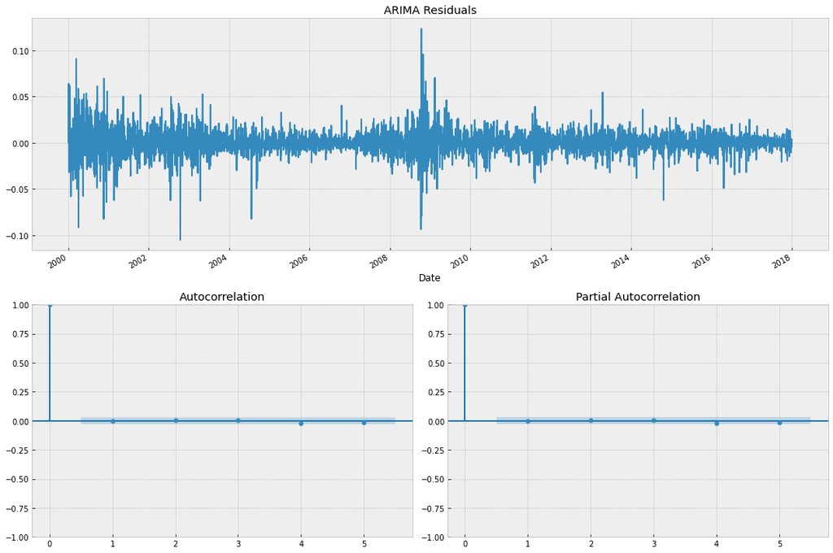

```python
tsplot(results_aic.resid, title="ARIMA Residuals", lags=5)
```

```python
sm.stats.acorr_ljungbox(results_aic.resid,lags=5, boxpierce=True, return_df = True)
```

|  | lb_stat | lb_pvalue | bp_stat | bp_pvalue |
| --- | --- | --- | --- | --- |
| 1 | 0.069021 | 0.792767 | 0.068976 | 0.792834 |
| 2 | 0.127238 | 0.938363 | 0.127141 | 0.938408 |
| 3 | 0.306741 | 0.958756 | 0.306446 | 0.958812 |
| 4 | 2.168965 | 0.704715 | 2.166203 | 0.705221 |
| 5 | 3.122665 | 0.681081 | 3.118428 | 0.681733 |

Up to lag 5, the ACF and PACF plots do not show any significant coefficients. The Box tests have large p-values, meaning we cannot reject the null, and should regard the residual sequence as White Noise.

## ARCH Effects

```python
sm.stats.acorr_ljungbox(results_aic.resid ** 2,lags=10, boxpierce=True, return_df = True)
```

|  | lb_stat | lb_pvalue | bp_stat | bp_pvalue |
| --- | --- | --- | --- | --- |
| 1 | 281.246936 | 4.016698e-63 | 281.060639 | 4.410279e-63 |
| 2 | 603.699672 | 8.096210e-132 | 603.228586 | 1.024653e-131 |
| 3 | 762.998708 | 4.578316e-165 | 762.351756 | 6.324205e-165 |
| 4 | 899.407470 | 2.238930e-193 | 898.579804 | 3.383507e-193 |
| 5 | 1008.370434 | 9.261532e-216 | 1007.374355 | 1.521724e-215 |
| 6 | 1123.685389 | 1.565177e-239 | 1122.485618 | 2.845536e-239 |
| 7 | 1201.343367 | 3.617657e-255 | 1199.989275 | 7.099737e-255 |
| 8 | 1304.572639 | 2.414423e-276 | 1302.990617 | 5.305990e-276 |
| 9 | 1354.352501 | 5.625355e-286 | 1352.649575 | 1.312279e-285 |
| 10 | 1484.584041 | 0.000000e+00 | 1482.536054 | 0.000000e+00 |

```python
# Engle Test
etest = sm.stats.diagnostic.het_arch(results_aic.resid, nlags = 10)
print('pval Lagrange: ' + str(np.round(etest[1],4)))
print('pval F-test: ' + str(np.round(etest[1],4)))
etest
```

```
pval Lagrange: 0.0
pval F-test: 0.0
```

```
(622.7549183324542,
 2.3389558452228067e-127,
 72.05847611430839,
 2.766030135813962e-137)
```

The Ljung-Box test seems to suggest there are autocorrelations in our data (squared residuals), while the Engle test suggest that the residuals exhibit heteroskedasticity. There is ARCH effects and a volatility model is needed.

## GARCH model

Note: we use a scaled residual sequence to fit the model.

```python
gm = arch_model(results_aic.resid * 100, p = 2, q = 2)
res_scaled = gm.fit()
```

[output not shown]

```python
print(res_scaled.summary())
```

```
                     Constant Mean - GARCH Model Results
==============================================================================
Dep. Variable:                   None   R-squared:                       0.000
Mean Model:             Constant Mean   Adj. R-squared:                  0.000
Vol Model:                      GARCH   Log-Likelihood:               -6785.96
Distribution:                  Normal   AIC:                           13583.9
Method:            Maximum Likelihood   BIC:                           13622.4
                                        No. Observations:                 4527
Date:                Thu, Apr 28 2022   Df Residuals:                     4526
Time:                        18:03:35   Df Model:                            1
                                 Mean Model
============================================================================
                 coef    std err          t      P>|t|      95.0% Conf. Int.
----------------------------------------------------------------------------
mu             0.0301  1.483e-02      2.030  4.233e-02 [1.043e-03,5.918e-02]
                               Volatility Model
=============================================================================
                 coef    std err          t      P>|t|       95.0% Conf. Int.
-----------------------------------------------------------------------------
omega          0.0153  6.743e-03      2.264  2.360e-02  [2.047e-03,2.848e-02]
alpha[1]       0.0724  2.899e-02      2.497  1.252e-02    [1.557e-02,  0.129]
alpha[2]   5.3297e-12  1.778e-02  2.998e-10      1.000 [-3.484e-02,3.484e-02]
beta[1]        0.7434      0.303      2.452  1.421e-02      [  0.149,  1.338]
beta[2]        0.1746      0.304      0.575      0.565      [ -0.420,  0.770]
=============================================================================

Covariance estimator: robust
```

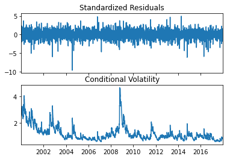

```python
garch_resid = res_scaled.resid
st_garch_resid = np.divide(garch_resid, res_scaled.conditional_volatility)
fig = res_scaled.plot()
```

```python
sm.stats.acorr_ljungbox(st_garch_resid ** 2,lags=10, boxpierce=True, return_df = True)
```

|  | lb_stat | lb_pvalue | bp_stat | bp_pvalue |
| --- | --- | --- | --- | --- |
| 1 | 0.807515 | 0.368856 | 0.806981 | 0.369014 |
| 2 | 7.344085 | 0.025424 | 7.337777 | 0.025505 |
| 3 | 7.415846 | 0.059761 | 7.409458 | 0.059931 |
| 4 | 8.148070 | 0.086302 | 8.140712 | 0.086558 |
| 5 | 8.151305 | 0.148092 | 8.143943 | 0.148479 |
| 6 | 8.511495 | 0.202972 | 8.503497 | 0.203486 |
| 7 | 8.743913 | 0.271569 | 8.735453 | 0.272212 |
| 8 | 9.002884 | 0.342053 | 8.993852 | 0.342815 |
| 9 | 9.747039 | 0.371349 | 9.736200 | 0.372260 |
| 10 | 10.212696 | 0.422035 | 10.200623 | 0.423072 |

```python
etest_garch = sm.stats.diagnostic.het_arch(st_garch_resid, nlags = 10)
print('pval Lagrange: ' + str(np.round(etest_garch[1],4)))
print('pval F-test: ' + str(np.round(etest_garch[1],4)))
etest_garch
```

```
pval Lagrange: 0.4263
pval F-test: 0.4263
```

```
(10.162580243357679,
 0.4263473083946894,
 1.0160691924636058,
 0.4267201886626978)
```

1. The ARCH effects have largely been eliminated. Up to 10 lags, despite the lag 2, 3 are around 5% p-values, all the other lags suggest we accept the null. Also, the Engle test null cannot be rejected.
2. From the model output we see that, $\beta_2$ and $\alpha_2$ are not significant (p-value ~ 55%), and $\alpha_2$ has a zero coefficient, so it is not effectively functioning in this model.

## Forecasting

### ARIMA

```python
log_returns = pd.concat([train, test])
n_train = len(train)
n_test = len(test)
train_start, train_end = train.index[0].strftime("%Y-%m-%d"), train.index[-1].strftime("%Y-%m-%d")
test_start, test_end = test.index[0].strftime("%Y-%m-%d"), test.index[-1].strftime("%Y-%m-%d")
```

```python
# Obtain the predictions
arima_predictions = pd.Series(
    data=results_aic.forecast(n_test).to_numpy(),
    index=test.index,
)
```

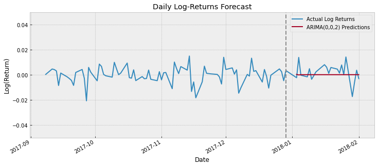

```python
PLOT_STYLE = "bmh"
with plt.style.context(PLOT_STYLE):
    fig, ax = plt.subplots(1, 1, figsize=(12, 5))
    log_returns[-100:].plot(ax=ax, label="Actual Log Returns")
    arima_predictions.plot(ax=ax, label="ARIMA(0,0,2) Predictions")
    ax.axvline(train_end, color="gray", alpha=0.9, linestyle="dashed")
    ax.set(
        title="Daily Log-Returns Forecast",
        ylabel="Log(Return)",
        ylim=(-0.05, 0.05),
    )
    ax.legend()
None
```

### GARCH

```python
# predicted values
forecasts_vol_scaled = res_scaled.forecast(horizon=len(test),reindex = False)
forecasts_df = pd.DataFrame()
forecasts_df['ActualReturn'] = test.values
forecasts_df['PredictedVolScaled'] = np.sqrt(forecasts_vol_scaled.variance.values[-1,:])
forecasts_df['Date'] = test.index
# previous returns and volatilities
pre_df = pd.DataFrame()
pre_df['ActualReturn'] = train.values
pre_df['ConditionalVolScaled'] = res_scaled.conditional_volatility.values
pre_df['Date'] = train.index
```

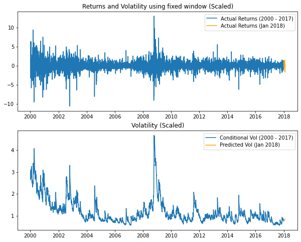

```python
fig = plt.figure(figsize=(10,8))
return_ax = fig.add_subplot(2,1,1)
return_ax.set_title("Returns and Volatility using fixed window (Scaled)")
plt.plot(train*100, label = "Actual Returns (2000 - 2017)")
plt.plot(test*100, label = "Actual Returns (Jan 2018)", color = 'orange')
plt.legend();

vol_ax = fig.add_subplot(2,1,2)
vol_ax.set_title("Volatility (Scaled)")
plt.plot(pre_df['Date'],pre_df['ConditionalVolScaled'], label = "Conditional Vol (2000 - 2017)")
plt.plot(forecasts_df['Date'], forecasts_df['PredictedVolScaled'], label = "Predicted Vol (Jan 2018)", color = 'orange')
plt.legend();
```

To zoom in the predictions, we have the following:

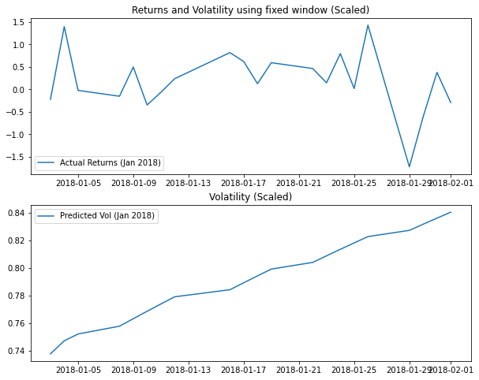

```python
fig = plt.figure(figsize=(10,8))
return_ax = fig.add_subplot(2,1,1)
return_ax.set_title("Returns and Volatility using fixed window (Scaled)")
# plt.plot(train*100, label = "Actual Returns (2000 - 2017)")
plt.plot(test*100, label = "Actual Returns (Jan 2018)")
plt.legend();

vol_ax = fig.add_subplot(2,1,2)
vol_ax.set_title("Volatility (Scaled)")
# plt.plot(pre_df['Date'],pre_df['ConditionalVolScaled'], label = "Conditional Vol (2000 - 2017)")
plt.plot(forecasts_df['Date'], forecasts_df['PredictedVolScaled'], label = "Predicted Vol (Jan 2018)")
plt.legend();
```